# PROBABILITY

## 2.2 iii) Summary statistics

For each value of $p$, determine 1st Quartile, median, mean, standard deviation and the 3rd Quartile.

### 2.2.1 Function to calculate summary statistics

```r
summaryStat <- function(n, p){
  Prob <- p
  Quart_1 <- qbinom(0.25, size=n, prob=p)
  Median <- qbinom(0.5, size=n, prob=p)
  Mean <- n * p
  Std <- sqrt(n * p * (1 - p))
  Quart_3 <- qbinom(0.75, size=n, prob=p)
  data.frame(Prob, Quart_1, Median, Mean, Std, Quart_3)
}
```

### 2.2.2 Table I: Summary Statistics

```r
pander(rbind(summaryStat(60, 0.3), summaryStat(60, 0.5), summaryStat(60, 0.8)))
```

| Prob | Quart_1 | Median | Mean | Std | Quart_3 |
| --- | --- | --- | --- | --- | --- |
| 0.3 | 16 | 18 | 18 | 3.55 | 20 |
| 0.5 | 27 | 30 | 30 | 3.873 | 33 |
| 0.8 | 46 | 48 | 48 | 3.098 | 50 |

The above table shows how the values change alonge the different $p$ values.

## 2.3 iv) Boxplot

Present those values as a vertical box plot with the probability p on the horizontal axis.

In order to generate a boxplot the easiest way is to simulate the data with different probabilty values ($p$). A number of 100’000 trials should be sufficient so that the real values lie close to simulated ones. *Note:* The central limit theorem (CLT) shows, that from a n>30 the mean of the values distribute themself normally around the true value.

### 2.3.1 Generate data

```r
# Simulation
set.seed(123) # Set random seed
df_sim <- data.frame(Prob_0.3=rbinom(100000, size = 60, prob = 0.3),
                     Prob_0.5=rbinom(100000, size = 60, prob = 0.5),
                     Prob_0.8=rbinom(100000, size = 60, prob = 0.8))
df_sim2 <- melt(df_sim)
```

### 2.3.2 Table II: Simulated data

```r
pander(summary(df_sim))
```

| Prob_0.3 | Prob_0.5 | Prob_0.8 |
| --- | --- | --- |
| Min. : 5.00 | Min. :13.00 | Min. :33.00 |
| 1st Qu.:16.00 | 1st Qu.:27.00 | 1st Qu.:46.00 |
| Median :18.00 | Median :30.00 | Median :48.00 |
| Mean :17.99 | Mean :30.03 | Mean :48.02 |
| 3rd Qu.:20.00 | 3rd Qu.:33.00 | 3rd Qu.:50.00 |
| Max. :34.00 | Max. :46.00 | Max. :59.00 |

The above table shows, that the summary statistics of the simulated data gives the same numbers as seen before. We can therefore safely assume, that the numbers are correct.

### 2.3.3 Summary statistics

In order to visualize the summary values in the boxplot format a function that compute the mean-1SE, and Mean+1SE has to be written.

```r
newSummaryStat <- function(x) {
  vec_var <- c(min(x), mean(x) - sd(x)/sqrt(length(x)), mean(x),
               mean(x) + sd(x)/sqrt(length(x)), max(x))
  names(vec_var) <- c("ymin", "lower", "middle", "upper", "ymax")
  vec_var
}
```

### 2.3.4 Visualize

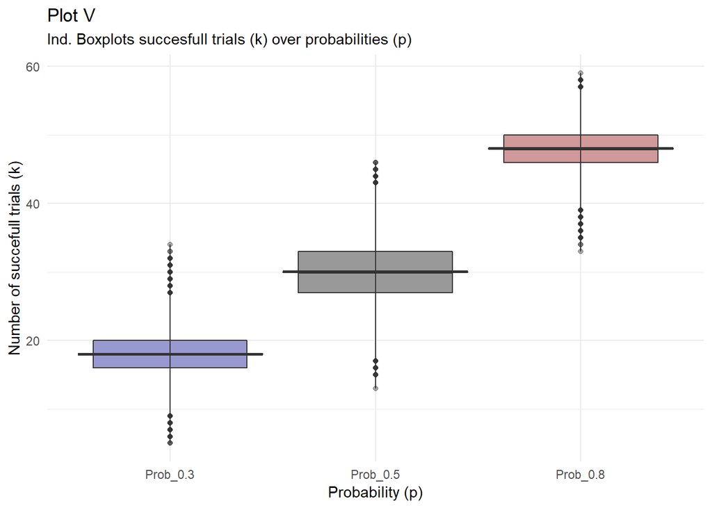

```r
ggplot(data=df_sim2, aes(x=variable, y=value)) +
  geom_boxplot(fill=c("darkblue", "black", "darkred"), alpha=0.4) +
  labs(title="Plot V",
       subtitle="Ind. Boxplots succesfull trials (k) over probabilities (p)") +
  stat_summary(fun.data=newSummaryStat, geom="boxplot") +
  theme_minimal() +
  ylab("Number of succefull trials (k)") +
  xlab("Probability (p)")
```